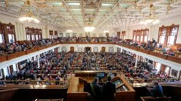

# HB2 Section by Section

Author

Dan Swart, Trustee (with Claude Sonnet 4.0)

### Texas HB2 Article 1: Teacher Compensation and Education Reforms

Analysis covers Article 1 (Teacher Compensation) only - Sections 1.01 through 1.11. Analysis stops before Section 2.01 (Article 2). Document spans pages 1-6 of legislative text.

### Texas HB2 Article 2: Educator Preparation and Teacher Rights

Analysis of Article 2 (Educator Preparation and Teacher Rights). Analysis covers Sections 2.01 through 2.24, focusing on educator preparation programs, certification requirements, and partnership programs. Document spans pages 6-19 of legislative text.

### Texas HB2 Article 3: Rights of Public School Educators - Incentives and Likely Results

Analysis covers Article 3 (Rights of Public School Educators) only - Sections 3.01 through 3.15. Analysis focuses on educator employment policies, certification processes, contract protections, and classroom management rights. Document spans pages 19-25 of legislative text.

### Texas HB2 Article 4: Special Education (Sections 4.01-4.15) - Incentives and Likely Results

Analysis covers Article 4 (Special Education) only - Sections 4.01 through 4.15. Analysis focuses on special education agency duties, compliance monitoring, eligibility criteria, interagency coordination, and residential placement oversight. Document spans pages 25-31 of legislative text.

### Texas HB2 Article 4: Special Education (Sections 4.16-4.26) - Incentives and Likely Results

Analysis covers Article 4 (Special Education) only - Sections 4.16 through 4.26. Analysis focuses on community support services grants, hospital education funding, special education service groups, transition funding formulas, dyslexia program requirements, representative qualifications, and IEP facilitation programs. Document spans pages 32-36 of legislative text.

### Texas HB2 Article 4: Special Education (Sections 4.27-4.40) - Incentives and Likely Results

Analysis covers Article 4 (Special Education) only - Sections 4.27 through 4.40. Analysis focuses on parent-directed services programs, provider autonomy protections, IEP committee duties, commissioner determination finality, and dyslexia teacher training grants. Document spans pages 37-40 of legislative text.

### Texas HB2 Article 4: Special Education Funding and Services (Sections 4.50-4.65) - Incentives and Likely Results

Analysis covers Article 4 (Special Education) Sections 4.50 through 4.65 only. Analysis focuses on special education funding formulas, dyslexia program requirements, special transportation services, day placement programs, parent-directed services grants, regional day school programs, and various special education administrative requirements. Document spans pages 47-54 of legislative text.

### Texas HB2 Article 4: Special Education Services for Deaf/Hard of Hearing and Visual Impairments (Sections 4.41-4.49) - Incentives and Likely Results

Analysis covers Article 4 (Special Education) Sections 4.41 through 4.49 only. Analysis focuses on language acquisition assessment, state plan requirements, visual impairment education mandates, Texas School funding adjustments, regional day school programs, and school offense complaint procedures. Document spans pages 40-47 of legislative text.

### Texas HB2 Article 5: Early Childhood Education (Sections 5.01-5.09) - Incentives and Likely Results

Analysis covers Article 5 (Early Childhood Education) Sections 5.01 through 5.09 only. Analysis focuses on open-enrollment charter school requirements, teacher literacy and mathematics achievement academies, school year planning grants, reading readiness assessments, early literacy instruments, and reading intervention programs. Document spans pages 55-59 of legislative text.

### Texas HB2 Article 5: Early Childhood Education (Sections 5.10-5.17) - Incentives and Likely Results

Analysis covers Article 5 (Early Childhood Education) Sections 5.10 through 5.17 only. Analysis focuses on early literacy and numeracy instruments, reading intervention programs, mathematics training requirements, supplementary supports programs, prekindergarten expansions, and early education reporting requirements. Document spans pages 59-66 of legislative text.

### Texas HB2 Article 5: Sections 5.17-5.26 - Incentives and Likely Results

Analysis covers Article 5 Sections 5.17 through 5.26 only. Analysis focuses on prekindergarten teacher qualifications, resource campus requirements, open education resource programs, dyslexia screening modifications, regional reporting changes, and funding formula adjustments. Document spans pages 66-70 of legislative text.

### Texas HB2 Article 5: Sections 5.27-5.32 - Incentives and Likely Results

Analysis covers Article 5 Sections 5.27 through 5.32 only. Analysis focuses on early education allotment distribution, literacy intervention funding, third grade supplementary supports, and various code repeals. Document spans pages 70-72 of legislative text.

### Texas HB2 Article 6: Sections 6.01-6.11 - Incentives and Likely Results

Analysis covers Article 6 Sections 6.01 through 6.11 only. Analysis focuses on college, career, and military readiness provisions including new education goals, postsecondary outcomes tracking, counselor requirements, and assessment options. Document excludes Section 6.12 and all subsequent content.

### Texas HB2 Article 6: Sections 6.12-6.31 - Incentives and Likely Results

Analysis covers Article 6 Sections 6.12 through 6.31 only. Analysis focuses on accountability system changes, industry certification requirements, funding modifications, and workforce data collection. Document excludes Section 7.01 and all subsequent content.

### Texas HB2 Article 7: Sections 7.01-7.19 - Public Education Finance Changes

Analysis covers Article 7 Sections 7.01 through 7.19 only. Analysis focuses on facility reporting requirements, charter school funding modifications, district allotment changes, and commissioner authority expansions. Document excludes Section 8.01 and all subsequent content.